# Pei_Final

Vanessa

2024-11-29

```r
library(tidyverse) #calling package
```

```r
library(ggplot2) #calling package
library(dplyr) #calling package
library(readxl) #calling package
```

Call in the Equity in Athletics Survey dataset, and selected relvent variable for analysis. The institution sector was grouped to compare public(0) and private(1) colleges using variale sector type.

```r
sport_df <- read_xlsx("EADA_2023.xlsx") %>% #read in the Equity in Athletics Survey dataset
  rename(UNITID = unitid) %>% #rename unitid to UNITID, preparing for merge with College Scorecard
  select(UNITID, sector_cd, STUDENTAID_MEN, STUDENTAID_WOMEN, IL_SUM_PARTIC_MEN,  IL_SUM_PARTIC_WOMEN, RECRUITEXP_MEN, RECRUITEXP_WOMEN, HDCOACH_SALARY_MEN, HDCOACH_SALARY_WOMEN, IL_MEN_TOTAL_HEADCOACH, IL_WOMEN_TOTAL_HDCOACH, NUM_ASCOACH_MEN, NUM_ASCOACH_WOMEN, IL_PARTIC_MEN, IL_PARTIC_WOMEN, IL_OPEXPPERPART_MEN, IL_OPEXPPERPART_WOMEN, ClassificationCode) %>% #select relevant columns
  mutate(
    sector_type = case_when(
      sector_cd %in% c(1, 4) ~ 0,   # sector_cd 1 and 4 are public college
      sector_cd %in% c(2, 3, 5) ~  1)) %>% # sector_cd 2,3,5 are private college
  select(-sector_cd)

#glimpse(sport_df)
```

Call in the College Scorecard dataset, and selected relvent variable for analysis.

```r
score_df <- read_csv("MERGED2022_23_PP.csv") %>% #read in the the College Scorecard dataset
  select (UNITID, SATVR25, SATVR75, SATMT25, SATMT75, ACTCM25, ACTCM75, ACTEN25, ACTEN75, ACTMT25, ACTMT75, ADM_RATE, COSTT4_A) #select relevant columns
#glimpse(score_df)
```

To prepare a single dataset for analysis, the tibbles from the Equity in Athletics Survey and the College Scorecard were merged using the common identifier UNITID, which is consistent across both datasets. This ensures that each institution is correctly matched based on its unique identifier. The resulting dataset combines relevant variables from both sources, creating a comprehensive dataset for further analysis.

The ourcome variables were dropped to avoid multicollinearity in the correlation analysis.

```r
sport_score_df <- sport_df %>%
  left_join(score_df, by = "UNITID") %>% #merge the two databases
  drop_na() %>% #drop rows with NA values
  select(-STUDENTAID_MEN, -STUDENTAID_WOMEN) #unselect the outcome variables
```

The correlation analysis was conducted to explore the relationships between the variables in the dataset.

PCA requires the removal of variables with strong multicollinearity (r>0.9) to ensure that the components accurately represent the variance in the data without redundancy.

```r
glimpse(sport_score_df)
```

```
## Rows: 773
## Columns: 29
## $ UNITID                 <dbl> 100654, 100663, 100706, 100724, 100751, 100830,…
## $ IL_SUM_PARTIC_MEN      <dbl> 228, 249, 278, 257, 373, 111, 336, 339, 245, 34…
## $ IL_SUM_PARTIC_WOMEN    <dbl> 168, 231, 217, 170, 400, 102, 307, 169, 122, 16…
## $ RECRUITEXP_MEN         <dbl> 0, 621937, 18882, 306202, 3519340, 9949, 240770…
## $ RECRUITEXP_WOMEN       <dbl> 0, 234816, 19023, 73539, 489512, 21711, 960598,…
## $ HDCOACH_SALARY_MEN     <dbl> 78772, 457860, 67521, 120506, 2389477, 50171, 1…
## $ HDCOACH_SALARY_WOMEN   <dbl> 48856, 89344, 68344, 68251, 276787, 48611, 2800…
## $ IL_MEN_TOTAL_HEADCOACH <dbl> 7, 6, 5, 6, 7, 5, 7, 9, 6, 10, 6, 6, 7, 8, 6, 6…
## $ IL_WOMEN_TOTAL_HDCOACH <dbl> 9, 9, 6, 8, 10, 6, 10, 9, 6, 10, 10, 6, 8, 9, 8…
## $ NUM_ASCOACH_MEN        <dbl> 13, 19, 9, 21, 27, 3, 27, 14, 19, 16, 17, 18, 1…
## $ NUM_ASCOACH_WOMEN      <dbl> 4, 14, 9, 14, 26, 4, 25, 8, 7, 8, 12, 8, 11, 26…
## $ IL_PARTIC_MEN          <dbl> 228, 248, 278, 257, 373, 111, 336, 339, 245, 34…
## $ IL_PARTIC_WOMEN        <dbl> 168, 224, 217, 170, 400, 102, 307, 169, 122, 16…
```

[output cut: 16 more lines]

```r
sport_score_tib <- sport_score_df[,2:29] #UNITID is not needed for analysis, so it is removed for correlation analysis

corr_sport_score_tib <- cor(sport_score_tib)

#corr_sport_score_tib
```

From the result, variables with r>0.9 and should be removed for PCA are RECRUITEXP_WOMEN, HDCOACH_SALARY_WOMEN, IL_PARTIC_MEN, IL_PARTIC_WOMEN, IL_OPEXPPERPART_WOMEN, SATVR25, SATVR75, ACTEN25, ACTEN75.

Remove variables with strong multicollinearity (r>0.9),

```r
score_sport_tib <- sport_score_tib %>%
    select(-c(RECRUITEXP_WOMEN, HDCOACH_SALARY_WOMEN, IL_PARTIC_MEN, IL_PARTIC_WOMEN, IL_OPEXPPERPART_WOMEN, SATVR25, SATVR75, ACTEN25, ACTEN75))

glimpse(score_sport_tib)
```

```
## Rows: 773
## Columns: 19
## $ IL_SUM_PARTIC_MEN      <dbl> 228, 249, 278, 257, 373, 111, 336, 339, 245, 34…
## $ IL_SUM_PARTIC_WOMEN    <dbl> 168, 231, 217, 170, 400, 102, 307, 169, 122, 16…
## $ RECRUITEXP_MEN         <dbl> 0, 621937, 18882, 306202, 3519340, 9949, 240770…
## $ HDCOACH_SALARY_MEN     <dbl> 78772, 457860, 67521, 120506, 2389477, 50171, 1…
## $ IL_MEN_TOTAL_HEADCOACH <dbl> 7, 6, 5, 6, 7, 5, 7, 9, 6, 10, 6, 6, 7, 8, 6, 6…
## $ IL_WOMEN_TOTAL_HDCOACH <dbl> 9, 9, 6, 8, 10, 6, 10, 9, 6, 10, 10, 6, 8, 9, 8…
## $ NUM_ASCOACH_MEN        <dbl> 13, 19, 9, 21, 27, 3, 27, 14, 19, 16, 17, 18, 1…
## $ NUM_ASCOACH_WOMEN      <dbl> 4, 14, 9, 14, 26, 4, 25, 8, 7, 8, 12, 8, 11, 26…
## $ IL_OPEXPPERPART_MEN    <dbl> 59038, 131806, 20812, 25252, 374798, 15681, 336…
## $ ClassificationCode     <dbl> 2, 1, 5, 2, 1, 5, 1, 6, 9, 6, 2, 4, 2, 1, 5, 1,…
## $ sector_type            <dbl> 0, 0, 0, 0, 0, 0, 0, 1, 1, 1, 0, 0, 1, 0, 1, 0,…
## $ SATMT25                <dbl> 400, 590, 613, 399, 560, 500, 610, 560, 480, 50…
## $ SATMT75                <dbl> 510, 720, 730, 510, 720, 575, 700, 610, 560, 58…
## $ ACTCM25                <dbl> 15, 23, 25, 16, 23, 18, 24, 22, 17, 18, 16, 17,…
## $ ACTCM75                <dbl> 19, 30, 30, 20, 31, 25, 30, 29, 24, 24, 23, 21,…
## $ ACTMT25                <dbl> 15, 20, 23, 14, 22, 16, 22, 20, 16, 16, 16, 16,…
## $ ACTMT75                <dbl> 18, 28, 30, 18, 29, 23, 28, 26, 23, 23, 22, 20,…
## $ ADM_RATE               <dbl> 0.6840, 0.8668, 0.7810, 0.9660, 0.8006, 0.9223,…
## $ COSTT4_A               <dbl> 23167, 26257, 25777, 21900, 31024, 19771, 33650…
```

```r
corr_sport_score_tib_2 <- cor(score_sport_tib)

#corr_sport_score_tib_2
```

Scaling ensures that each variable contributes equally to the PCA computation. This is important because variables with larger scales can dominate the analysis, leading to inaccurate results.

```r
library(psych)
scaled_score_sport <- score_sport_tib %>%
  mutate_at(c(1:19), ~(scale(.) %>% as.vector)) #scale all 18 variables

glimpse(scaled_score_sport)
```

```
## Rows: 773
## Columns: 19
## $ IL_SUM_PARTIC_MEN      <dbl> -0.41810450, -0.25287199, -0.02469378, -0.18992…
## $ IL_SUM_PARTIC_WOMEN    <dbl> -0.49437838, 0.16160039, 0.01582733, -0.4735536…
## $ RECRUITEXP_MEN         <dbl> -0.42152354, 0.45690162, -0.39485456, 0.0109568…
## $ HDCOACH_SALARY_MEN     <dbl> -0.30284256, 0.62113825, -0.33026550, -0.201121…
## $ IL_MEN_TOTAL_HEADCOACH <dbl> -0.2610882, -0.6348312, -1.0085741, -0.6348312,…
## $ IL_WOMEN_TOTAL_HDCOACH <dbl> 0.04866426, 0.04866426, -1.02612067, -0.3095973…
## $ NUM_ASCOACH_MEN        <dbl> -0.53480988, 0.09219928, -0.95281599, 0.3012023…
## $ NUM_ASCOACH_WOMEN      <dbl> -1.30398264, -0.02870610, -0.66634437, -0.02870…
## $ IL_OPEXPPERPART_MEN    <dbl> -0.046539467, 0.738095492, -0.458718667, -0.410…
## $ ClassificationCode     <dbl> -0.92875778, -1.22323266, -0.04533313, -0.92875…
## $ sector_type            <dbl> -1.2082601, -1.2082601, -1.2082601, -1.2082601,…
## $ SATMT25                <dbl> -1.62299482, 0.73280500, 1.01798077, -1.6353937…
## $ SATMT75                <dbl> -1.6748606, 1.1585817, 1.2935075, -1.6748606, 1…
## $ ACTCM25                <dbl> -1.38903131, 0.26634923, 0.68019436, -1.1821087…
## $ ACTCM75                <dbl> -2.1017070, 0.6392155, 0.6392155, -1.8525323, 0…
## $ ACTMT25                <dbl> -1.16526928, -0.03678876, 0.64029956, -1.390965…
## $ ACTMT75                <dbl> -2.1411468, 0.4067388, 0.9163159, -2.1411468, 0…
## $ ADM_RATE               <dbl> -0.12004780, 0.69516929, 0.31253458, 1.13756281…
## $ COSTT4_A               <dbl> -1.00462813, -0.84272898, -0.86787836, -1.07101…
```

```r
psych::describe(scaled_score_sport) #make sure all means are 0, and sd is 1. This also gives us a lot of descriptives quickly
```

```
##                        vars   n mean sd median trimmed  mad   min  max range
## IL_SUM_PARTIC_MEN         1 773    0  1  -0.10   -0.06 0.92 -2.02 4.62  6.63
## IL_SUM_PARTIC_WOMEN       2 773    0  1  -0.12   -0.07 0.93 -2.06 5.17  7.23
## RECRUITEXP_MEN            3 773    0  1  -0.35   -0.26 0.08 -0.42 8.52  8.94
## HDCOACH_SALARY_MEN        4 773    0  1  -0.35   -0.27 0.10 -0.49 5.95  6.44
## IL_MEN_TOTAL_HEADCOACH    5 773    0  1  -0.26   -0.07 1.11 -2.13 4.60  6.73
## IL_WOMEN_TOTAL_HDCOACH    6 773    0  1   0.05   -0.06 1.06 -2.46 6.50  8.96
## NUM_ASCOACH_MEN           7 773    0  1  -0.01   -0.05 0.93 -1.89 4.90  6.79
## NUM_ASCOACH_WOMEN         8 773    0  1  -0.03   -0.07 0.95 -1.81 4.56  6.38
## IL_OPEXPPERPART_MEN       9 773    0  1  -0.42   -0.26 0.21 -0.67 4.88  5.55
## ClassificationCode       10 773    0  1  -0.05   -0.09 0.87 -1.22 4.37  5.60
## sector_type              11 773    0  1   0.83    0.05 0.00 -1.21 0.83  2.03
## SATMT25                  12 773    0  1  -0.14   -0.09 0.74 -2.74 3.21  5.95
## SATMT75                  13 773    0  1  -0.19   -0.06 1.00 -4.24 2.24  6.48
## ACTCM25                  14 773    0  1  -0.15   -0.08 0.92 -4.29 2.75  7.04
## ACTCM75                  15 773    0  1  -0.11    0.00 1.11 -4.59 2.13  6.73
## ACTMT25                  16 773    0  1  -0.26   -0.11 1.00 -4.33 3.35  7.67
## ACTMT75                  17 773    0  1  -0.10   -0.02 0.76 -4.94 2.45  7.39
## ADM_RATE                 18 773    0  1   0.24    0.14 0.79 -3.03 1.29  4.32
## COSTT4_A                 19 773    0  1  -0.15   -0.08 1.18 -1.73 2.19  3.92
##                         skew kurtosis   se
## IL_SUM_PARTIC_MEN       0.68     0.92 0.04
## IL_SUM_PARTIC_WOMEN     0.87     1.72 0.04
## RECRUITEXP_MEN          4.00    18.97 0.04
## HDCOACH_SALARY_MEN      3.50    12.54 0.04
## IL_MEN_TOTAL_HEADCOACH  0.82     1.34 0.04
## IL_WOMEN_TOTAL_HDCOACH  1.06     4.55 0.04
## NUM_ASCOACH_MEN         0.57     0.55 0.04
## NUM_ASCOACH_WOMEN       0.72     0.61 0.04
## IL_OPEXPPERPART_MEN     2.55     6.20 0.04
## ClassificationCode      1.43     3.80 0.04
## sector_type            -0.38    -1.86 0.04
## SATMT25                 0.86     0.83 0.04
## SATMT75                 0.34     0.06 0.04
## ACTCM25                 0.55     0.24 0.04
## ACTCM75                -0.13    -0.06 0.04
## ACTMT25                 0.78     0.38 0.04
## ACTMT75                 0.05     0.64 0.04
## ADM_RATE               -1.23     1.07 0.04
## COSTT4_A                0.49    -0.95 0.04
```

This is just to understand the underlying data. The correlation between a variable and a principal component (PC) is used as the coordinates of the variable on the PC. The length of the vector represents the correlation between the variable and the PC, while the angle between vectors indicates the correlation between variables.

```r
library(factoextra) #extract and visualize the output of multivariate data analyses, including 'PCA'
```

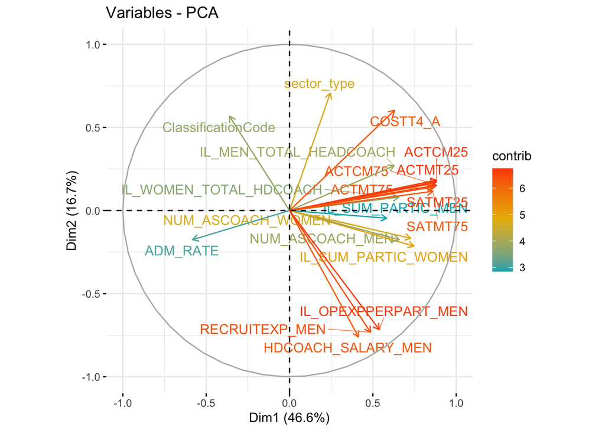

```r
#line below runs a simple PCA with a component for each variable.
#the most variance will be explained in component 1 and 2
viz_pca <- prcomp(scaled_score_sport, center = TRUE,scale. = TRUE)


#Graph of variables. Positive correlated variables point to the same side of the plot. Negative correlated variables point to opposite sides of the graph.

fviz_pca_var(viz_pca,
             col.var = "contrib", # Color by contributions to the PC
             gradient.cols = c("#00AFBB", "#E7B800", "#FC4E07"),
             repel = TRUE #Avoid overlapping text if possible
             )
```

Through visualization, it seems that the following are loading together: # 1. College sport team expenses  
# 2. SAT and ACT scores # 3. Number of coachs and participants

```r
cortest.bartlett(scaled_score_sport, 773) #there are 773 observations
```

```
## R was not square, finding R from data
```

```
## $chisq
## [1] 19158.62
##
## $p.value
## [1] 0
##
## $df
## [1] 171
```

```r
# Bartlett's test of sphericity is significant, indicating that the correlation matrix is not an identity matrix.
# p value below .05, so it is not an identity matrix
```

```r
KMO(scaled_score_sport)
```

```
## Kaiser-Meyer-Olkin factor adequacy
## Call: KMO(r = scaled_score_sport)
## Overall MSA =  0.85
## MSA for each item =
##      IL_SUM_PARTIC_MEN    IL_SUM_PARTIC_WOMEN         RECRUITEXP_MEN
##                   0.72                   0.81                   0.87
##     HDCOACH_SALARY_MEN IL_MEN_TOTAL_HEADCOACH IL_WOMEN_TOTAL_HDCOACH
##                   0.81                   0.78                   0.78
##        NUM_ASCOACH_MEN      NUM_ASCOACH_WOMEN    IL_OPEXPPERPART_MEN
##                   0.78                   0.81                   0.87
##     ClassificationCode            sector_type                SATMT25
##                   0.83                   0.66                   0.91
##                SATMT75                ACTCM25                ACTCM75
##                   0.92                   0.90                   0.91
##                ACTMT25                ACTMT75               ADM_RATE
##                   0.92                   0.93                   0.93
##               COSTT4_A
##                   0.84
```

```r
#all data above .50 and overall MSA is strong
```